# CONCEPTION - Demonstration project 4: Migraine

Creation of the pregnancy study population

General information:

- **Script directory:** /Users/vhoxhaj/Desktop/DP4_Migraine_GitHub/Demonstration project/DP4_Migraine
- **Date/time:** 2023-04-11 10:55:23
- **DAP:** ARS
- **Data source:** ARS

| DAP | Script | Start_date | End_date | Time_elaspsed |
| --- | --- | --- | --- | --- |
| ARS | Step_01_create_study_population.R | 2023-04-11 | 2023-04-11 | 0.19 secs |

Start and end study dates for all projects by DAP

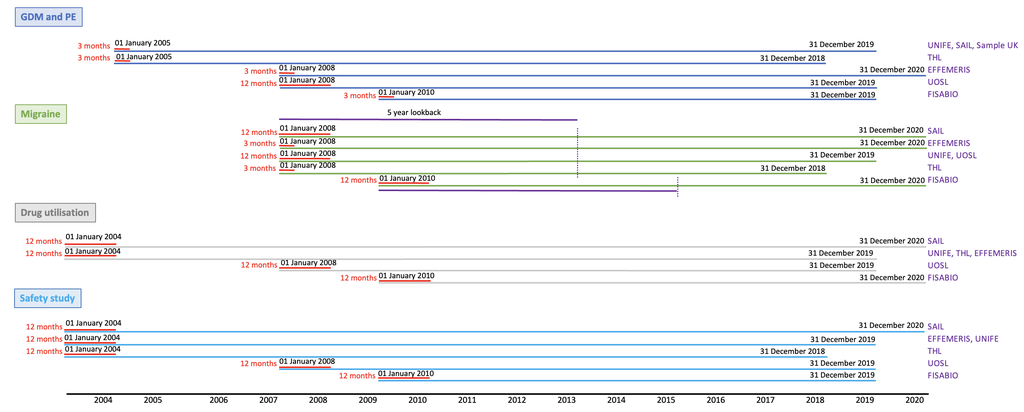

Study dates

**Study dates for the DAP of interest**

[output not shown]

## 1. Application of the same exclusion criteria to OBSERVATION_PERIODS and PERSONS table

**Step 1:** Load the OBSERVATION_PERIODS table and apply the CreateSpells function.  
**Step 2:** Clean up the OBSERVATION_PERIODS table.  
**Step 3:** Load the PERSONS table, clean up records and impute date of birth and date of death when needed.

spells- observation period, the time span between start of follow up and end of follow up

Below all indicators and number of removed records is explained.

|  | Indicator | no_records |
| --- | --- | --- |
| 1 | 1.0. Number of original records in the OBSERVATION_PERIODS table | 3187 |
| 2 | 1.1. Number of records in the OBSERVATION_PERIODS table after cleaning up the spells | 1115 |
| 3 | 1.2. Number of records in the OBSERVATION_PERIODS table after keeping one record per person(latest) | 1097 |
| 4 | 2.0. Number of original records in the PERSONS table | 1192 |
| 5 | 2.1. Number of records in the PERSONS table with sex other than female | 505 |
| 6 | 2.2. Number of records in the PERSONS table with empty year of birth | 0 |
| 7 | 2.3. Number of records in the PERSONS table with empty year of death, when date or/and month of death are present | 0 |
| 8 | 2.4. Number of records in the PERSONS table where only day of birth was imputed | 0 |
| 9 | 2.5. Number of records in the PERSONS table where only day of death was imputed | 0 |
| 10 | 2.6. Number of records in the PERSONS table where both day and month of birth were imputed | 0 |

[output cut: 2 more lines]

## 2. Creation of the pregnancy study population and application of specific exclusion criteria

**Step 1:** Merge the OBSERVATION_PERIODS table with PERSONS table.  
**Step 2:** Clean up the created table by removing subjects with no follow up in the study period.  
**Step 3:** Check for impossible birthdates(>120 years old at end follow up).  
**Step 4:** Merge with the Pregnancy D3 created in Step 0.  
**Step 5:** Compare pregnancy dates with start and end of follow up dates.  
**Step 6:** Check age at start of pregnancy date.  
**Step 7:** Check lookback time by comparing start of follow up and pregnancy start date.  
**Step 8:** Check the neccessary follow up period, type of pregnancy(multiple, single).  
**Step 9:** Create the pregnancy study population for each project.

Below all indicators and number of removed records is explained.

|  | Indicator | GDM_and_PE | Migraine | Drug_utilisation | Safety |
| --- | --- | --- | --- | --- | --- |
| 1 | 3.0. Number of records present in PERSONS but not in OBSERVATION_PERIODS | 101 | 101 | 101 | 101 |
| 2 | 3.1. Number of records with follow up &lt;1 day | 60 | 60 | 60 | 60 |
| 3 | 3.2. Number of subjects with age&gt;120 years old at end follow up | 0 | 0 | 0 | 0 |
| 4 | 4.0. Number of subjects present in the pregnancy D3 but missing in the PERSONS table | 0 | 0 | 0 | 0 |
| 5 | 4.1. Number of pregnancies included after merging with the PERSONS table | 108 | 141 | 141 | 141 |
| 6 | 4.2. Number of pregnancies with pregnancy start date before the minimum pregnancy date | 0 | 0 | 0 | 0 |
| 7 | 4.3. Number of pregnancies with pregnancy start date after the maximum pregnancy date | 0 | 0 | 0 | 0 |
| 8 | 4.4. Number of pregnancies with age at pregnancy start date &lt; 15years old | 1 | 1 | 1 | 1 |
| 9 | 4.5. Number of pregnancies with age at pregnancy start date &gt; 49years old | 4 | 4 | 4 | 4 |
| 10 | 4.6. Number of records with lookback period less than 3 months | 6 | 6 | 6 | 6 |

[output cut: 7 more lines]

## 3. Summary of included records for all projects by year of start pregnancy date

|  | year | GDM_and_PE | Migraine | Drug_utilisation | Safety |
| --- | --- | --- | --- | --- | --- |
| 1 | 2009 | 4 | 7 | 7 | 7 |
| 2 | 2010 | 9 | 18 | 18 | 18 |
| 3 | 2011 | 5 | 7 | 7 | 7 |
| 4 | 2012 | 13 | 16 | 16 | 16 |
| 5 | 2013 | 7 | 10 | 10 | 10 |
| 6 | 2014 | 9 | 9 | 9 | 9 |
| 7 | 2015 | 11 | 17 | 17 | 17 |
| 8 | 2016 | 11 | 13 | 13 | 13 |
| 9 | 2017 | 17 | 18 | 18 | 18 |
| 10 | 2018 | 10 | 14 | 14 | 14 |

Author: Vjola Hoxhaj Drs.  
email: v.hoxhaj@umcutrecht.nl  
Organisation: UMC Utrecht, Utrecht, The Netherlands